# Problema 1 - Checkpoint 4 - Relatório Final

```r
library(tidyr)
library(dplyr)
library(readr)
library(ggplot2)

theme_set(theme_minimal())
```

```r
series <- read_csv("series_from_imdb.csv")
```

## O episódios *season finale* são considerados melhores que os demais?

Os episódios que encerram as temporadas são os que costumam causar mais *frisson*, em geral eles são repletos de suspense, reviravoltas, drama e tudo mais que prenda a nossa atenção e nos deixe sedentos pela próxima temporada.  
Mas será que as séries estão conseguindo realmente fazer isso? Será que esses episódios são melhores que os demais?  
Para responder a essa pergunta usamos os dados das 31 séries disponíveis e classificamos os episódios em *Episódio final* para os episódios que encerram uma temporada de uma séria e *Episódio final* para os demais e comparamos a qualidade destes dois grupos.

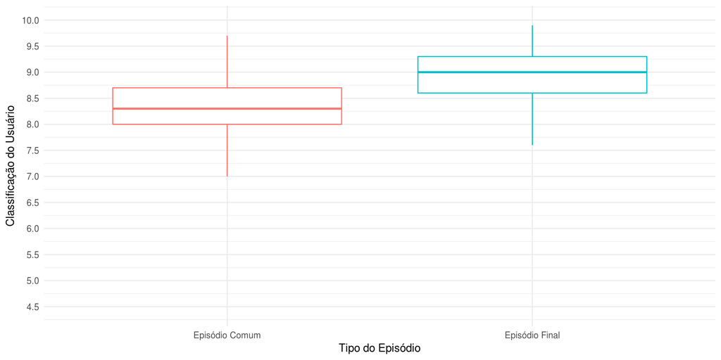

```r
  season_finale_eps <- series %>%
    group_by(series_name, season) %>%
    summarise(season_ep = max(season_ep))

  season_finale_eps$is.finale <- TRUE

  series <- right_join(season_finale_eps, series, by = c("series_name", "season", "season_ep"))

  series$is.finale <- ifelse(is.na(series$is.finale), FALSE, TRUE)
series$class_ep <- ifelse(series$is.finale, "Episódio Final", "Episódio Comum")

ggplot(series, aes(x = class_ep, y = UserRating, color = class_ep)) +
  geom_boxplot(outlier.shape = NA) +
  scale_y_continuous(breaks = seq(4,10,.5)) +
  labs(y = "Classificação do Usuário", x = "Tipo do Episódio" ) +
  theme(legend.position = "none")
```

Percebe-se que realmente **os episódios finais apresentam uma classificação superior do que os demais episódios das séries** se observarmos a mediana de cada grupo.

Vamos observar agora específicamente os valores de média e mediana dos episódios comuns e finais, para termos a noção exata da diferença entre eles

| Tipo do Episódio | Média | Mediana |
| --- | --- | --- |
| Comum | 8.25 | 8.3 |
| Final | 8.81 | 9 |

Agora fica possível mensurar a diferença exata entre os episódios finais das temporadas e os demais além de podermos analisar também a diferença entre a mediana e a média dos dados, que baixa para os dois tipos de episódios, significando a pouca incidência de outliers (dados que são muito diferentes dos demais) na avaliação das séries.

## Os episódios que encerram as temporadas representam picos na avaliação das séries?

Já sabendo que a *season finale* costuma receber melhores avaliações que os demais episódios, será que no decorrer da série eles representam os picos de avaliação das séries? Em que situação estão as séries antes e depois deles?  
A base de dados disponível conta com 31 séries, sabendo que pode ser difícil e/ou extenso visualizar o comportamento de todas essas séries, então serão selecionadas as 6 séries estudadas da parte 1 desta mesma atividade, que foram:

- Agents of S.H.I.E.L.D.
- House of Cards
- Orphan Black
- The 100
- The Blacklist
- Vikings

Os episódios finais de cada temporada são demarcados por pontos na linha de cada série.

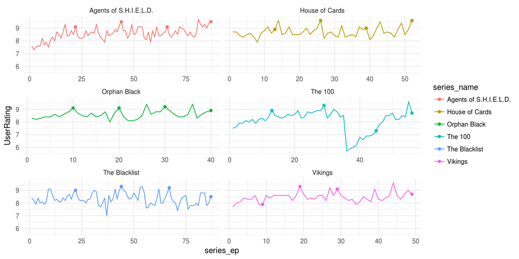

```r
sub_series <- filter(series, series_name %in% c("Agents of S.H.I.E.L.D.", "House of Cards", "Orphan Black", "The 100", "The Blacklist", "Vikings"))

ggplot(sub_series, aes(x = series_ep, y = UserRating, color = series_name)) +
  geom_line() +
  geom_point(data = filter(sub_series, is.finale), aes(color = series_name)) +
  facet_wrap(~series_name, scales = "free_x", ncol = 2)
```

## Séries com muitos episódios tendem a ser melhor avaliadas ao longo do tempo?

Se uma série dura deve-se esperar que ela fique melhor a cada temporada, ou pelo menos que mantenha um nível mínimo de qualidade não é mesmo? É? **Afinal, longevidade é sinônimo de qualidade?**  
Para responder essa questão usaremos as séries que tem mais de 100 episódios nos nossos dados e estudaremos como se comporta a avaliação dos usuários no decorrer destes episódios. As linhas tracejadas representam a mediana da avaliação de cada série.

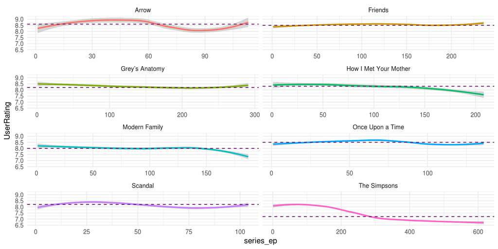

```r
series_longas <- series %>%
  group_by(series_name) %>%
  summarise(eps = max(series_ep),
            mediaUR = mean(UserRating),
            medianaUR = median(UserRating)) %>%
  filter(eps >= 100)

data_series_longas <- filter(series, series_name %in% c(series_longas$series_name))

ggplot(data_series_longas, aes(x = series_ep, y = UserRating, color = series_name)) +
  geom_smooth() +
  facet_wrap(~series_name, scales = "free_x", ncol = 2) +
  geom_hline(data = series_longas, aes(yintercept = medianaUR), linetype="dashed", colour="#660066") +
  theme(legend.position = "none")
```

## E séries curtas, agradam mais os expectadores?

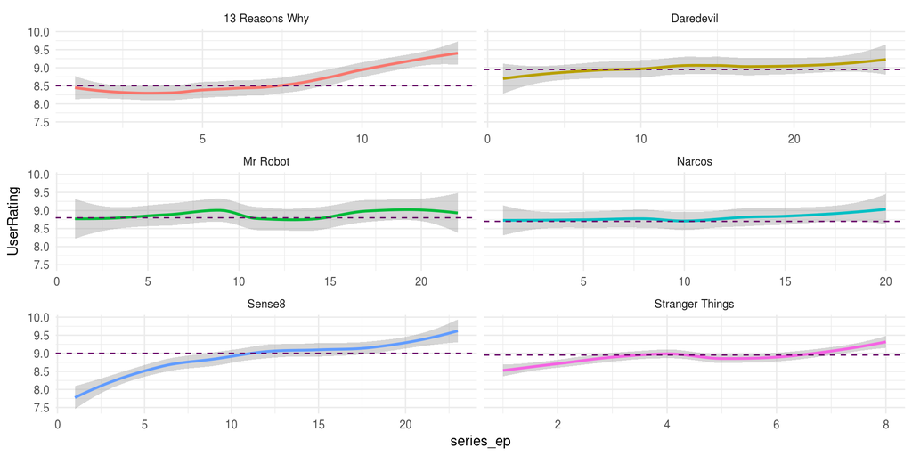

```r
series_curtas <- series %>%
  group_by(series_name) %>%
  summarise(n_seasons = max(season),
            mediaUR = mean(UserRating),
            medianaUR = median(UserRating)) %>%
  filter(n_seasons <= 2)

data_series_curtas <- filter(series, series_name %in% c(series_curtas$series_name))

ggplot(data_series_curtas, aes(x = series_ep, y = UserRating, color = series_name)) +
  geom_smooth() +
  facet_wrap(~series_name, scales = "free_x", ncol = 2) +
  geom_hline(data = series_curtas, aes(yintercept = medianaUR), linetype="dashed", colour="#660066") +
  theme(legend.position = "none")
```

Ao contrário das séries longas, as séries curtas apresentam **melhora na avaliação** dos episódios se aprensentando através do formato crescente da linha definida para a avaliação das séries.